# NEU 290 Data Assignment 2: Visualizing Birth Data

Harlee Scordo

# Visualization and Interpretation Exercises

This document explores several questions about maternal and newborn health by visualizing data in the 2004 North Carolina births registry. Make sure to replace all questions with your answers and to fill in code in each code chunk with a … in it.

##Setup Libraries Set up the libraries required for visualizations.

```r
#If you get an error saying dplyr or ggplot2 have not been found, then you have not installed them yet! To install them, "uncomment" the next two lines by deleting the hash/pound symbol and try again!
#install.packages("dyplr")
#install.packages("ggplot2")
library(dplyr)
library(ggplot2)
library(tidyverse)
```

## Load Data

The following loads a dataset that was released in 2004 from the state of North Carolina and includes information about about the maternal and newborn health from 800 randomly chosen live births in that state.

```r
# Run this to load the data! It's OK if it doesn't make sense yet!
id <- '19vUudLrACnxKpP-X0M_6wGdf2Suid1_a'
births <- read.csv(sprintf("https://docs.google.com/uc?id=%s&export=download", id))
```

## Explore the Data

Have a look at the variables recorded in this dataset. Each row is one birth.

```r
glimpse(births)
```

```
## Rows: 800
## Columns: 13
## $ fage           <int> 19, 21, 18, 17, 20, 30, 21, 14, 16, 20, 18, 20, 20, 26,…
## $ mage           <int> 15, 15, 15, 15, 16, 16, 16, 16, 16, 17, 17, 17, 17, 17,…
## $ mature         <chr> "younger mom", "younger mom", "younger mom", "younger m…
## $ weeks          <int> 37, 41, 37, 35, 37, 45, 38, 40, 24, 40, 37, 40, 39, 38,…
## $ premie         <chr> "premie", "full term", "premie", "premie", "premie", "f…
## $ visits         <int> 11, 6, 12, 5, 13, 9, 15, 12, 5, 8, 10, 17, 9, 11, 10, 1…
## $ marital        <chr> "married", "married", "married", "married", "married", …
## $ gained         <int> 38, 34, 76, 15, 52, 28, 75, 9, 12, 20, 39, 38, 36, 30, …
## $ weight         <dbl> 6.63, 8.00, 8.44, 4.69, 6.94, 7.44, 7.56, 5.81, 1.50, 8…
## $ lowbirthweight <chr> "not low", "not low", "not low", "low", "not low", "not…
## $ gender         <chr> "female", "male", "male", "male", "female", "male", "fe…
## $ habit          <chr> "nonsmoker", "nonsmoker", "nonsmoker", "nonsmoker", "no…
## $ whitemom       <chr> "white", "white", "not white", "not white", "white", "w…
```

Most of the variables have transparent names, but some are a little less apparent:

- fage - father’s age at time of birth
- mage - mother’s age at time of birth
- weeks - duration of pregnancy in weeks
- visits - the number of prenatal care visits to a clinician that the mother attended during pregnancy
- gained - the maximum amount of weight gained by the mother during pregnancy (in pounds)
- weight - the weight of the newborn infant (in pounds)
- gender - the gender identified on NC birth registry for the newborn infant

## Exercise 0: Example

This “Exercise” is an example to show how you could format exercises 1-5. Your exercises should look similar to this, with one or two code chunks, followed by your answer to the provided question (having deleted the original question text).

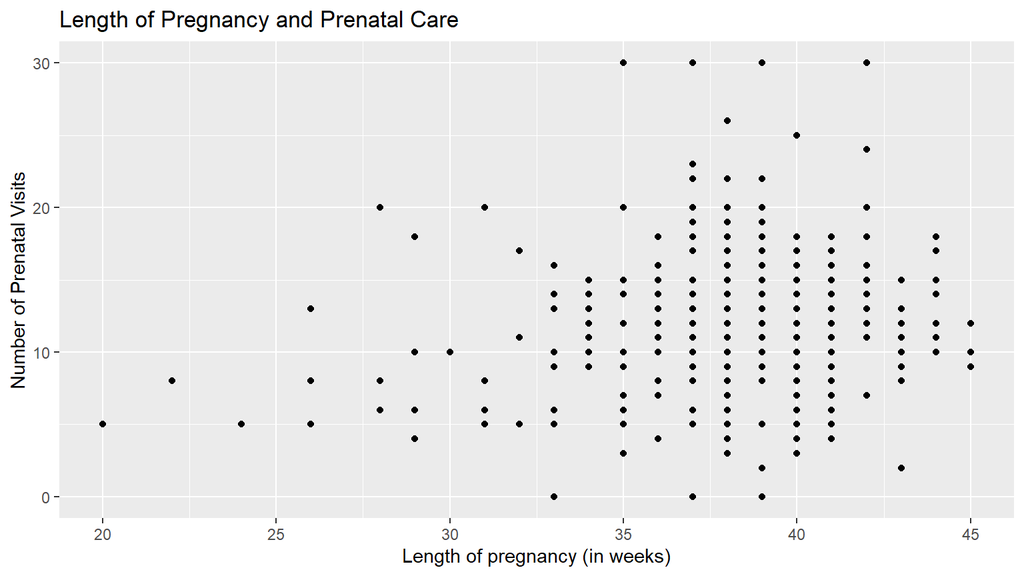

```r
births %>%
  ggplot(aes(x = weeks, y = visits)) +
  geom_point() +
    labs(x = "Length of pregnancy (in weeks)",
         y = "Number of Prenatal Visits",
         title = "Length of Pregnancy and Prenatal Care")
```

As seen in the above figure, there is perhaps a week relationship between length of pregnancy and number of visits to prenatal care appointments. Mother’s with shorter pregnancies rarely attended that many visits, but this is not surprising as there was simply less time to attend or schedule such visits. Some mothers who had longer pregnancies also attended few or even zero appointments.